# FoQR_HW2

# Number 3

First we modify the code to explore over a range of values of N, increasing the max time, t to make it clear where dN/dt ends up for each starting value of N (Please ignore the warning messages. I have no idea how to supress them. I tried using warning=FALSE like we learned in comp bio but it doesnt work for these warnings for some reason)

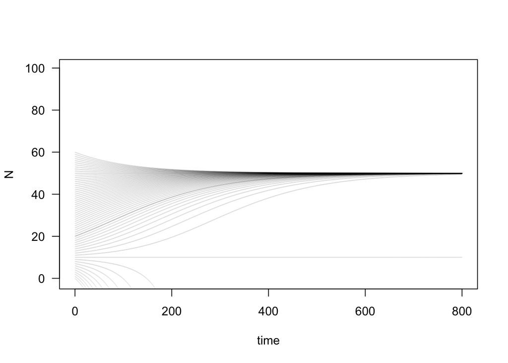

[output not shown]

[output cut: 545 more lines]

[output not shown]

```r
require(deSolve)
## Loading required package: deSolve
# Initial values
state <- c(N=20)
times <- seq(0,800,by=0.1)

# Parameters
parameters <- c(b = 2.4,c=0.02,M=50,d=0.2)

# Model
sterile_insect <- function(t,state,parameters){
  with(as.list(c(state,parameters)),{
    dN <- b*N/(N+M) - d - c*N
    list(c(dN))
  })}

# Solve model and plot results
out <- ode(y = state,times=times,func=sterile_insect,parms=parameters)
par(mfrow=c(1,1))
plot(out[,1],out[,2],ylab='N',xlab='time',las=1, ylim=c(-1, 100), pch=20, cex = .001 )

##Plot the population curve for multiple starting values of N on the same plot

states = seq(0, 60,by=1)

for (currState in states){
  state <- c(N=currState)
  times <- seq(0,800,by=0.1)

  # Parameters
  parameters <- c(b = 2.4,c=0.02,M=50,d=0.2)

  # Model
  sterile_insect <- function(t,state,parameters){
    with(as.list(c(state,parameters)),{
      dN <- b*N/(N+M) - d - c*N
      list(c(dN))
    })}

  # Solve model and plot results
  out <- ode(y = state,times=times,func=sterile_insect,parms=parameters)
  par(mfrow=c(1,1))
  points(out[,1],out[,2],ylab='N',xlab='time',las=1, pch=20, cex = .001)

}
```

From this plot it is clear that there are two equilibrium points with this paramter set, at N=10 and N=50, where N=10 is unstable, and N=50 is stable.

To “sketch” dN/dt as asked for, first we plot dN/dt using ggplot2’s stat_function

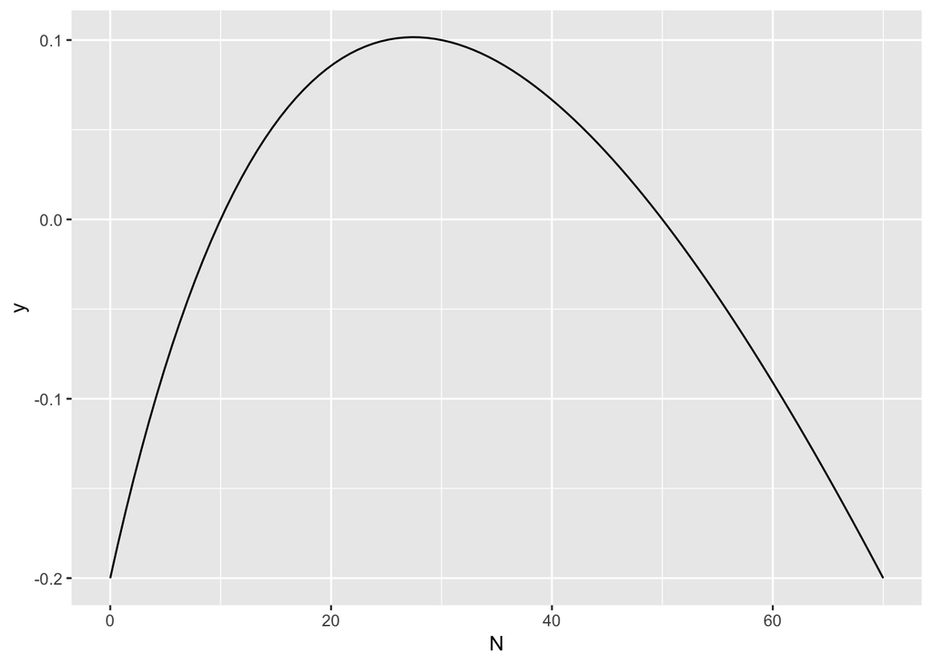

```r
library(ggplot2)

f <- ggplot(data.frame(N = c(0, 70)), aes(N))


b = 2.4
c=0.02
M=50
d=0.2


dN <- function(N) {b*N/(N+M) - d - c*N}
f + stat_function(fun = dN)
```

Now that we have created the plot, we can “sketch” on top of it to highlight the equilibrium points and their stability

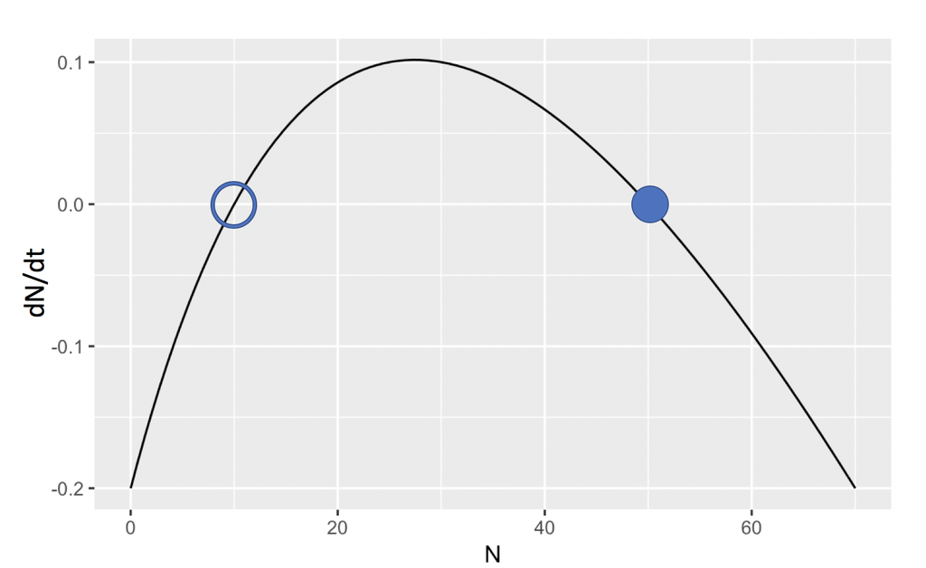